# Chapter 5

Mette Nissen

12/2/2019

# Chapter 5. Dimensionality reduction techniques

This week we are using human dataset from the United Nations Development Programme. From this dataset we have selected 8 variables wich are: country - Country Edu2.FM - secundry education rate female to male ratio Labo.FM - Labour force participation rate female to male ratio Life.Exp - Life expectancy at birth GNI - Gender Development Index Mat.Mor - Maternal mortality ratio Ado.Birth - Adolescent birth rate Parli.F - Percent of female representation in Parliament

## Data exploration

```r
human <- read.csv("data/human.csv", row.names = 1)

library(GGally)
library(tidyverse)
```

```r
library(corrplot)
library(dplyr)
library(knitr)
library(corrplot)
library(tidyr)
library(reshape2)
library(plotly)
library(FactoMineR)
library(ggplot2)


str(human)
```

```
## 'data.frame':    148 obs. of  8 variables:
##  $ Edu2.FM  : num  1.007 0.997 0.983 0.989 0.969 ...
##  $ Labo.FM  : num  0.891 0.819 0.825 0.884 0.829 ...
##  $ Edu.Exp  : num  17.5 20.2 15.8 18.7 17.9 16.5 18.6 16.5 15.9 19.2 ...
##  $ Life.Exp : num  81.6 82.4 83 80.2 81.6 80.9 80.9 79.1 82 81.8 ...
##  $ GNI      : int  64992 42261 56431 44025 45435 43919 39568 52947 42155 32689 ...
##  $ Mat.Mor  : int  4 6 6 5 6 7 9 28 11 8 ...
##  $ Ado.Birth: num  7.8 12.1 1.9 5.1 6.2 3.8 8.2 31 14.5 25.3 ...
##  $ Parli.F  : num  39.6 30.5 28.5 38 36.9 36.9 19.9 19.4 28.2 31.4 ...
```

```r
summary(human)
```

```
##     Edu2.FM          Labo.FM          Edu.Exp         Life.Exp
##  Min.   :0.1980   Min.   :0.1857   Min.   : 7.00   Min.   :49.00
##  1st Qu.:0.8097   1st Qu.:0.5971   1st Qu.:11.57   1st Qu.:68.38
##  Median :0.9444   Median :0.7504   Median :13.55   Median :74.35
##  Mean   :0.8766   Mean   :0.7006   Mean   :13.42   Mean   :72.44
##  3rd Qu.:0.9990   3rd Qu.:0.8385   3rd Qu.:15.32   3rd Qu.:77.45
##  Max.   :1.4967   Max.   :1.0380   Max.   :20.20   Max.   :83.50
##       GNI            Mat.Mor        Ado.Birth         Parli.F
##  Min.   :   680   Min.   :  1.0   Min.   :  0.60   Min.   : 0.00
##  1st Qu.:  5190   1st Qu.: 11.0   1st Qu.: 12.18   1st Qu.:12.15
##  Median : 12408   Median : 45.5   Median : 31.30   Median :19.50
##  Mean   : 18402   Mean   :120.9   Mean   : 43.72   Mean   :20.95
##  3rd Qu.: 25350   3rd Qu.:170.0   3rd Qu.: 69.05   3rd Qu.:27.82
##  Max.   :123124   Max.   :730.0   Max.   :175.60   Max.   :57.50
```

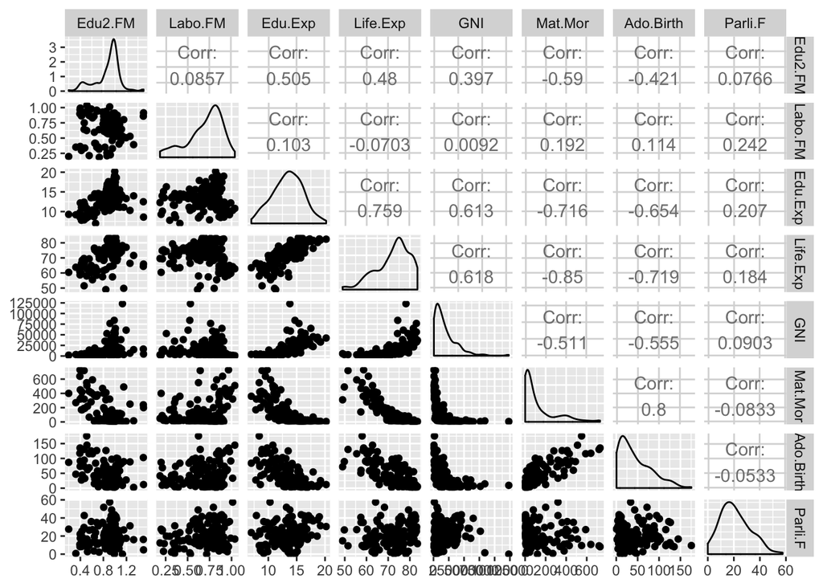

```r
pairs <- ggpairs(human)
pairs
```

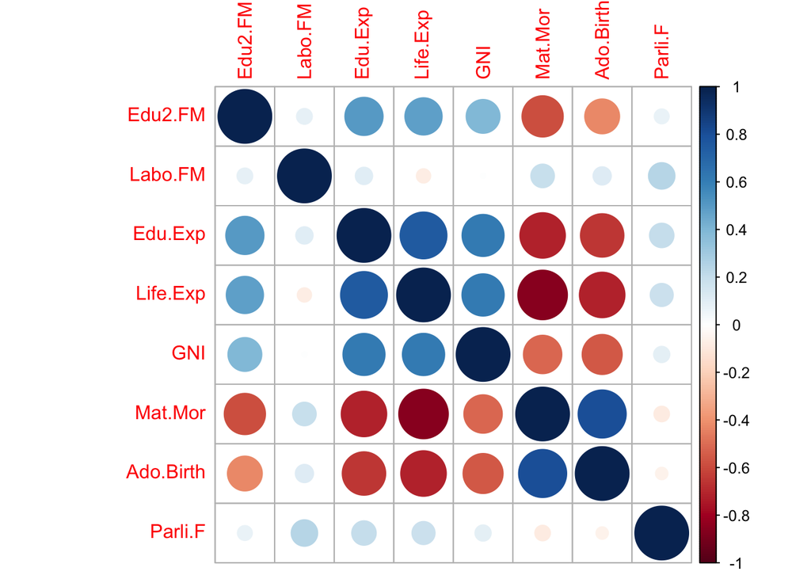

```r
# compute the correlation matrix and visualize it with corrplot
cor(human) %>% corrplot()
```

From the summary we can see that distributions differ between variables. GNI min is 680 and max is 123124 with comparison of Labo.FM with range of 0.1857-1.0380. In the dataset values are different. Correlation between variables differ from strongly positive correlation (maternal mortality - rate of adolescent women giving birth) to negative corelation (maternal mortality - life expectancy).

## Principal component analysis (PCA) on the not standardized human data

```r
#PCA analysis
pca_human <- prcomp(human)
pca_human
```

```
## Standard deviations (1, .., p=8):
## [1] 1.862483e+04 1.420218e+02 2.116337e+01 1.147634e+01 3.608478e+00
## [6] 1.571358e+00 1.923557e-01 1.512244e-01
##
## Rotation (n x k) = (8 x 8):
##                     PC1           PC2           PC3           PC4
## Edu2.FM   -4.649714e-06  0.0006867686 -0.0013662633  2.317587e-04
## Labo.FM   -9.719607e-08 -0.0003158778  0.0003015743  4.425582e-03
## Edu.Exp   -8.706739e-05  0.0087580112  0.0053006118  3.255666e-02
## Life.Exp  -2.533543e-04  0.0333850374 -0.0048336882  7.494569e-02
## GNI       -9.999893e-01 -0.0046050756 -0.0003728181 -6.050839e-05
## Mat.Mor    4.477844e-03 -0.9863064242  0.1609608588  1.124047e-02
## Ado.Birth  1.111169e-03 -0.1611663247 -0.9864335638 -3.008031e-02
## Parli.F   -5.580863e-05  0.0034657989 -0.0314144646  9.961287e-01
##                     PC5           PC6           PC7           PC8
## Edu2.FM   -0.0055155087  1.762118e-02  6.384062e-01  7.694765e-01
## Labo.FM    0.0052146757  3.217052e-02  7.688482e-01 -6.385848e-01
## Edu.Exp    0.1415081241  9.886674e-01 -3.580796e-02  8.073940e-03
## Life.Exp   0.9861585472 -1.437809e-01  4.420684e-03  6.632638e-03
## GNI       -0.0001023982 -2.864828e-05 -1.086468e-06 -1.752803e-06
## Mat.Mor    0.0337070459  2.675068e-03  1.432260e-04  1.224251e-03
## Ado.Birth  0.0039566221  7.122449e-03 -7.522696e-04 -1.109192e-03
## Parli.F   -0.0791032655 -2.145731e-02 -2.750969e-03  1.847856e-03
```

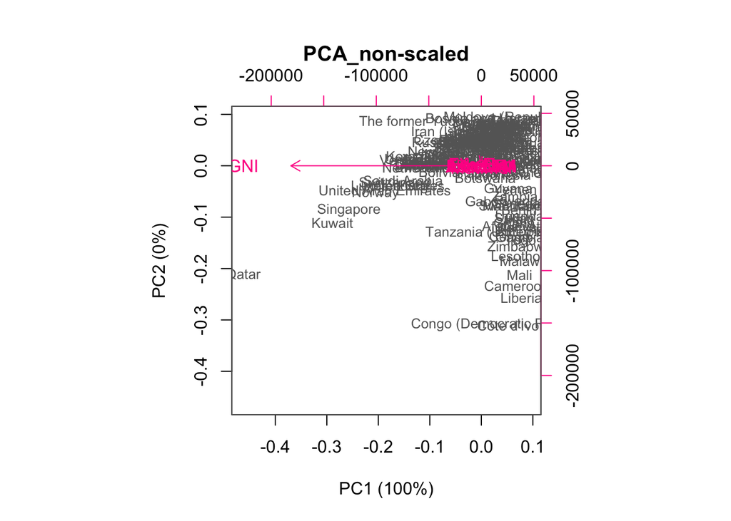

```r
#Summary of principal component analysis
s <- summary(pca_human)

# rounded percentages of variance captured by each PC
pca_pr <- round(100*s$importance[2,], digits = 1)

# creating an object pc_lab to be used as axis labels
pc_lab <- paste0(names(pca_pr), " (", pca_pr, "%)")

# drawing a biplot of the principal component representation and the original variables
biplot(pca_human, choices = 1:2, cex = c(0.8, 1), col = c("grey40", "deeppink"), xlab = pc_lab[1], ylab = pc_lab[2], main = (title = "PCA_non-scaled"))
```

From not scaled data pca is not useful because of large impact of GNI which has the largest SD and resulting first components 100% of variance. Therefore we must scale the data to make valid analysis.

## PCA on standardized data

```r
# standardize the variables
human_std <- scale(human)
summary(human_std)
```

```
##     Edu2.FM           Labo.FM           Edu.Exp            Life.Exp
##  Min.   :-3.1089   Min.   :-2.6159   Min.   :-2.42684   Min.   :-3.0723
##  1st Qu.:-0.3065   1st Qu.:-0.5256   1st Qu.:-0.69805   1st Qu.:-0.5329
##  Median : 0.3108   Median : 0.2531   Median : 0.04826   Median : 0.2503
##  Mean   : 0.0000   Mean   : 0.0000   Mean   : 0.00000   Mean   : 0.0000
##  3rd Qu.: 0.5610   3rd Qu.: 0.7005   3rd Qu.: 0.71899   3rd Qu.: 0.6566
##  Max.   : 2.8414   Max.   : 1.7144   Max.   : 2.56114   Max.   : 1.4495
##       GNI             Mat.Mor          Ado.Birth          Parli.F
##  Min.   :-0.9515   Min.   :-0.7355   Min.   :-1.1573   Min.   :-1.8197
##  1st Qu.:-0.7094   1st Qu.:-0.6742   1st Qu.:-0.8466   1st Qu.:-0.7643
##  Median :-0.3218   Median :-0.4626   Median :-0.3333   Median :-0.1258
##  Mean   : 0.0000   Mean   : 0.0000   Mean   : 0.0000   Mean   : 0.0000
##  3rd Qu.: 0.3730   3rd Qu.: 0.3009   3rd Qu.: 0.6799   3rd Qu.: 0.5973
##  Max.   : 5.6228   Max.   : 3.7352   Max.   : 3.5397   Max.   : 3.1749
```

```r
#PCA analysis with scaled variables
pca_human_std <- prcomp(human_std)
pca_human_std
```

```
## Standard deviations (1, .., p=8):
## [1] 2.0333042 1.1429035 0.8966375 0.7974445 0.7016064 0.5533825 0.4782085
## [8] 0.3039769
##
## Rotation (n x k) = (8 x 8):
##                   PC1         PC2         PC3         PC4        PC5
## Edu2.FM   -0.32465414  0.09227181 -0.43377536  0.71962839 -0.3646631
## Labo.FM    0.02176326  0.72972518 -0.51145278 -0.19826256  0.3349423
## Edu.Exp   -0.42571462  0.14257522 -0.03704407 -0.14368290  0.1144547
## Life.Exp  -0.44696256 -0.02108739  0.13444430 -0.07252202  0.1544074
## GNI       -0.36191020  0.03284391 -0.10502738 -0.55841503 -0.6927543
## Mat.Mor    0.44847613  0.16196165 -0.07472686 -0.20980104 -0.2594996
## Ado.Birth  0.41583795  0.14603035 -0.06162895  0.13254030 -0.3781145
## Parli.F   -0.08992529  0.62416308  0.71441898  0.20859522 -0.1663542
##                    PC6         PC7         PC8
## Edu2.FM   -0.102011694  0.06004801  0.18184654
## Labo.FM   -0.113322727 -0.17601955 -0.10061935
## Edu.Exp    0.611088764  0.62425612  0.01404528
## Life.Exp   0.296297409 -0.63847349  0.50711229
## GNI       -0.176468208 -0.08563262 -0.16340648
## Mat.Mor    0.004512949  0.24190007  0.77276191
## Ado.Birth  0.683004537 -0.31602881 -0.27395047
## Parli.F   -0.133691243  0.04841963 -0.02315017
```

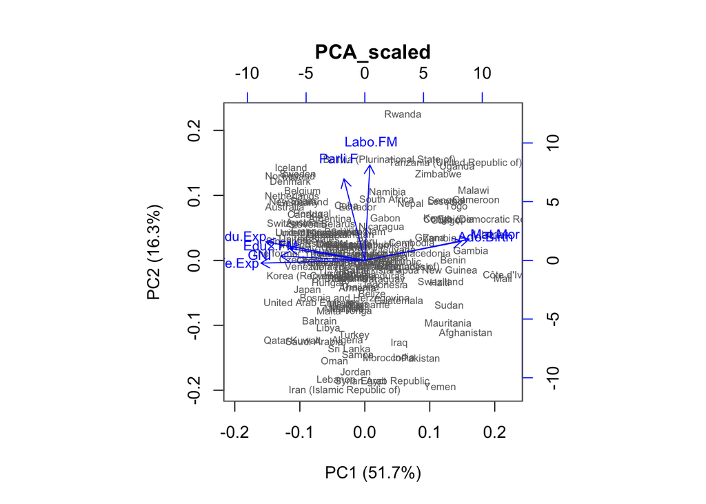

```r
# rounded percentages of variance captured by each PC
s_st <- summary(pca_human_std)
pca_pr_st <- round(100*s_st$importance[2,], digits = 1)

# creating an object pc_lab to be used as axis labels
pc_lab_st <- paste0(names(pca_pr_st), " (", pca_pr_st, "%)")

# drawing a biplot of the principal component representation and the original variables
biplot(pca_human_std, choices = 1:2, cex = c(0.6, 0.8), col = c("grey40", "blue"), xlab = pc_lab_st[1], ylab = pc_lab_st[2], main = (title = "PCA_scaled"))
```

With scaling analysis shows a more reliable result. Rwanda seems to be an outlier in this 2-dimensional biplot. PC1 + PC2 are accounted for 68% of the variance which is quite a lot.

## And now for somethin completely different - Tea

```r
data(tea)

# What is tea all about

dim(tea)
```

```
## [1] 300  36
```

```r
str(tea)
```

```
## 'data.frame':    300 obs. of  36 variables:
##  $ breakfast       : Factor w/ 2 levels "breakfast","Not.breakfast": 1 1 2 2 1 2 1 2 1 1 ...
##  $ tea.time        : Factor w/ 2 levels "Not.tea time",..: 1 1 2 1 1 1 2 2 2 1 ...
##  $ evening         : Factor w/ 2 levels "evening","Not.evening": 2 2 1 2 1 2 2 1 2 1 ...
##  $ lunch           : Factor w/ 2 levels "lunch","Not.lunch": 2 2 2 2 2 2 2 2 2 2 ...
##  $ dinner          : Factor w/ 2 levels "dinner","Not.dinner": 2 2 1 1 2 1 2 2 2 2 ...
##  $ always          : Factor w/ 2 levels "always","Not.always": 2 2 2 2 1 2 2 2 2 2 ...
##  $ home            : Factor w/ 2 levels "home","Not.home": 1 1 1 1 1 1 1 1 1 1 ...
##  $ work            : Factor w/ 2 levels "Not.work","work": 1 1 2 1 1 1 1 1 1 1 ...
##  $ tearoom         : Factor w/ 2 levels "Not.tearoom",..: 1 1 1 1 1 1 1 1 1 2 ...
##  $ friends         : Factor w/ 2 levels "friends","Not.friends": 2 2 1 2 2 2 1 2 2 2 ...
##  $ resto           : Factor w/ 2 levels "Not.resto","resto": 1 1 2 1 1 1 1 1 1 1 ...
##  $ pub             : Factor w/ 2 levels "Not.pub","pub": 1 1 1 1 1 1 1 1 1 1 ...
##  $ Tea             : Factor w/ 3 levels "black","Earl Grey",..: 1 1 2 2 2 2 2 1 2 1 ...
##  $ How             : Factor w/ 4 levels "alone","lemon",..: 1 3 1 1 1 1 1 3 3 1 ...
```

[output cut: 22 more lines]

```r
summary(tea)
```

```
##          breakfast           tea.time          evening          lunch
##  breakfast    :144   Not.tea time:131   evening    :103   lunch    : 44
##  Not.breakfast:156   tea time    :169   Not.evening:197   Not.lunch:256
##
##
##
##
##
##         dinner           always          home           work
##  dinner    : 21   always    :103   home    :291   Not.work:213
##  Not.dinner:279   Not.always:197   Not.home:  9   work    : 87
##
##
##
##
##
##         tearoom           friends          resto          pub
##  Not.tearoom:242   friends    :196   Not.resto:221   Not.pub:237
##  tearoom    : 58   Not.friends:104   resto    : 79   pub    : 63
##
##
##
##
##
##         Tea         How           sugar                     how
##  black    : 74   alone:195   No.sugar:155   tea bag           :170
##  Earl Grey:193   lemon: 33   sugar   :145   tea bag+unpackaged: 94
##  green    : 33   milk : 63                  unpackaged        : 36
##                  other:  9
##
##
##
##                   where                 price          age        sex
##  chain store         :192   p_branded      : 95   Min.   :15.00   F:178
##  chain store+tea shop: 78   p_cheap        :  7   1st Qu.:23.00   M:122
##  tea shop            : 30   p_private label: 21   Median :32.00
##                             p_unknown      : 12   Mean   :37.05
##                             p_upscale      : 53   3rd Qu.:48.00
##                             p_variable     :112   Max.   :90.00
##
```

[output cut: 25 more lines]

```
##  feminine    :129   Not.sophisticated: 85   No.slimming:255
##  Not.feminine:171   sophisticated    :215   slimming   : 45
##
##
##
##
##
##         exciting          relaxing              effect.on.health
##  exciting   :116   No.relaxing:113   effect on health   : 66
##  No.exciting:184   relaxing   :187   No.effect on health:234
##
##
##
##
##
```

Tea dataset includes 36 variables describing tea-taking habits with 300 observations. Most of the variables are strings and some are bimodal. This dataset is too large for a reasonable analysis and therefore I have picked variables with health attributes.

```r
# column names to keep in the dataset
keep_columns <- c("Tea", "sugar", "pub", "friends", "sport", "healthy", "effect.on.health", "slimming", "relaxing")

# selecting the 'keep_columns' to create a new dataset
tea_health <- select(tea, one_of(keep_columns))
# look at the summaries and structure of the tea_health data
summary(tea_health)
```

[output not shown]

```r
str(tea_health)
```

[output not shown]

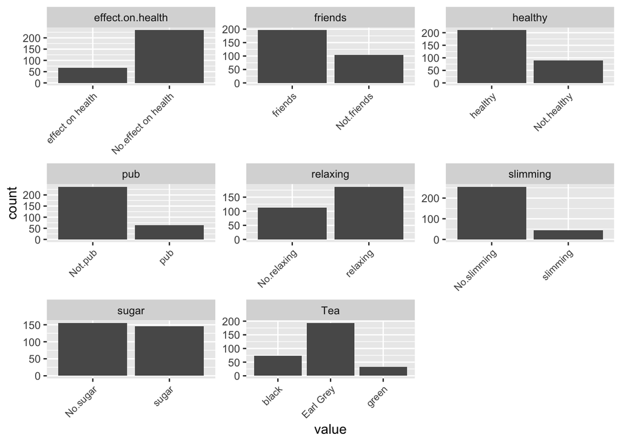

```r
gather(tea_health) %>% ggplot(aes(value)) + facet_wrap("key", scales = "free") + geom_bar() + theme(axis.text.x = element_text(angle = 45, hjust = 1, size = 8))
```

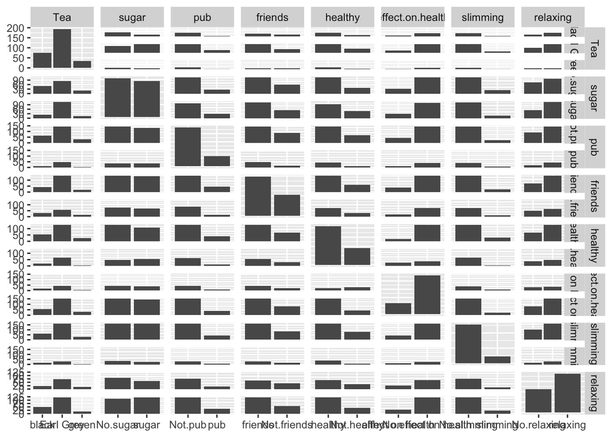

```r
pairs <- ggpairs(tea_health)
pairs
```

Most of the tea drinkers drink earl grey with friends. 210 think tea is healthy but only 66 think tea has an effect on health. Majority (187) think tea is relaxing. Sugar is used more often with Earl Grey

```r
# multiple correspondence analysis
mca <- MCA(tea_health, graph = FALSE)
# summary of the model
summary(mca)
```

```
##
## Call:
## MCA(X = tea_health, graph = FALSE)
##
##
## Eigenvalues
##                        Dim.1   Dim.2   Dim.3   Dim.4   Dim.5   Dim.6
## Variance               0.177   0.175   0.153   0.129   0.123   0.112
## % of var.             15.749  15.527  13.567  11.437  10.899   9.959
## Cumulative % of var.  15.749  31.275  44.842  56.279  67.178  77.137
##                        Dim.7   Dim.8   Dim.9
## Variance               0.099   0.087   0.071
## % of var.              8.804   7.731   6.329
## Cumulative % of var.  85.940  93.671 100.000
##
## Individuals (the 10 first)
##                Dim.1    ctr   cos2    Dim.2    ctr   cos2    Dim.3    ctr
## 1           | -0.309  0.179  0.087 |  0.395  0.298  0.142 | -0.111  0.027
## 2           | -0.530  0.528  0.259 |  0.622  0.739  0.357 |  0.121  0.032
## 3           | -0.202  0.076  0.086 | -0.251  0.120  0.133 | -0.036  0.003
## 4           | -0.129  0.031  0.025 | -0.184  0.065  0.052 | -0.346  0.261
## 5           |  0.133  0.033  0.020 |  0.269  0.138  0.082 | -0.136  0.040
## 6           | -0.350  0.230  0.191 |  0.043  0.003  0.003 | -0.114  0.028
## 7           | -0.202  0.076  0.086 | -0.251  0.120  0.133 | -0.036  0.003
## 8           | -0.610  0.700  0.390 |  0.323  0.200  0.110 |  0.221  0.106
## 9           |  0.133  0.033  0.020 |  0.269  0.138  0.082 | -0.136  0.040
## 10          | -0.610  0.700  0.390 |  0.323  0.200  0.110 |  0.221  0.106
##               cos2
## 1            0.011 |
## 2            0.014 |
## 3            0.003 |
## 4            0.181 |
## 5            0.021 |
## 6            0.020 |
## 7            0.003 |
## 8            0.051 |
## 9            0.021 |
## 10           0.051 |
##
## Categories (the 10 first)
```

[output cut: 18 more lines]

```
## pub          -8.957 |   0.345   2.053   0.032   3.080 |
## friends      -8.079 |   0.085   0.382   0.013   2.006 |
## Not.friends   8.079 |  -0.159   0.720   0.013  -2.006 |
## healthy      -5.999 |   0.021   0.025   0.001   0.549 |
##
## Categorical variables (eta2)
##                    Dim.1 Dim.2 Dim.3
## Tea              | 0.255 0.271 0.461 |
## sugar            | 0.138 0.144 0.131 |
## pub              | 0.006 0.268 0.032 |
## friends          | 0.057 0.218 0.013 |
## healthy          | 0.556 0.120 0.001 |
## effect.on.health | 0.345 0.131 0.181 |
## slimming         | 0.043 0.010 0.379 |
## relaxing         | 0.017 0.235 0.023 |
```

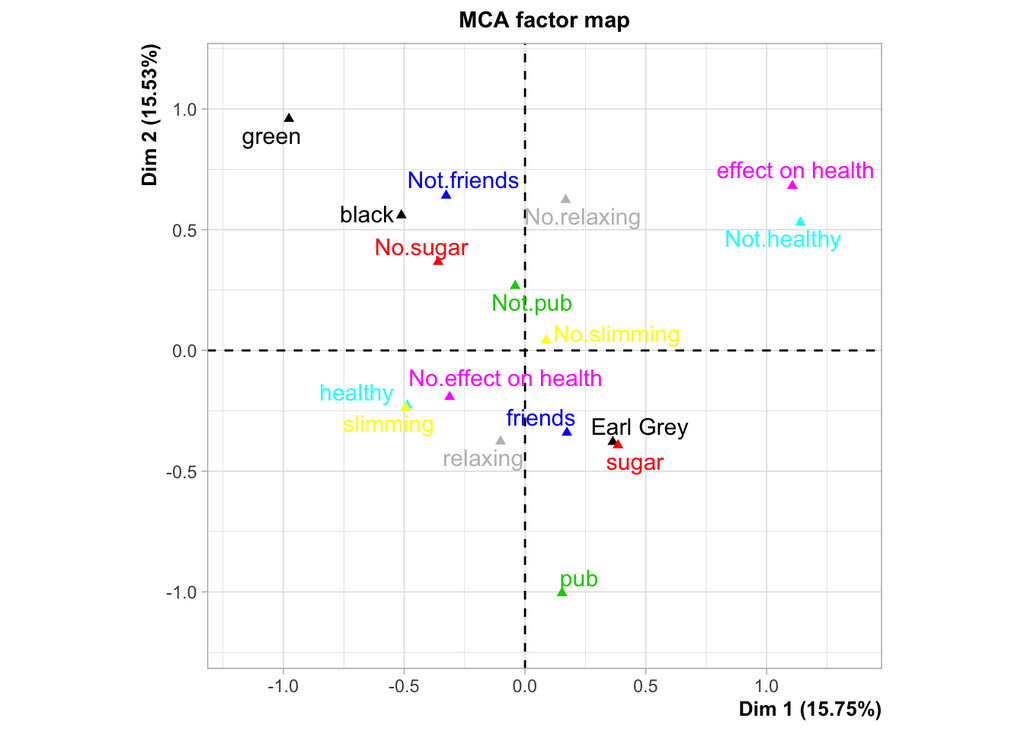

```r
# visualize MCA
plot(mca, invisible=c("ind"), habillage = "quali")
```

With this analysis we can see that 31.275% of this models variance can be explained with the first 2 dimensions. It seems that social aspect is more affected by the Dim 2 and ohysical health with Dim 1. According to minor clusters it seems that people drinking tea with friens use sugar and they think tea is relaxing compaired with people drinking tea without friends use black tea with no sugar.